# Document

McKinley Nevins

Collaborator

11/17/2020

Abstract

This is an abstract.

It consists of two paragraphs.

# Header 1

Biggest

# Header 1

Biggest

## Header 2

Big

### Header 3

Pretty big

#### Header 4

Bold header line

# Intro to Markdown Syntax

Here is an example of **bold** text. Another axample of **bold**. Here is an example of *italic* text. Another example of *italic*. Here is an example of *bold italic*. What about superscript x<sup>2</sup>. What about subscript x<sub>2</sub>. underlined text underlined text = no!

Here is an example of **bold** text. Another axample of **bold**. Here is an example of *italic* text. Another example of *italic*. Here is an example of *bold italic*. What about superscript x<sup>2</sup>.What about subscript x<sub>2</sub>. underlined text underlined text = no!

#### Line Breaks

Line 1  
Line 2

Line 1  
Line 2

* Note: The `<br>` doesn't do a new paragraph, just a line break.

#### Body of document

This is our report introduction and we want to include supporting informatino in the form of a blockquote from an important person in our field.

> This is a quote from an important person

> This person is *really* important

> > They also say this

Paragraph 2

Paragraph 3

#### Lists

A numbered list

1. item 1
2. item 2
3. item 3

A symbol list

- item 1
- item 2
- item 3
- item 1
- item 2
- item 3
- item 1
- item 2
- item 3

A list with a sublist

1. item 1
   1. subitem 1
2. item 2
   2. subitem 2
3. item 3
   3. subitem 3

> This is my **super** important list
> 1. item 1
> 2. item 2
> 3. item 3

Paragraphs or descriptions under list items

1. Item 1

   This is a description for item 1.
2. Item 2

   This is a description for item 2.
3. Item 3

   This is a description for item 3.

#### Tables in Markdown

Demonstration of a messy table.

| Col 1 | Col 2 | Col 3 | Col4 |
| --- | --- | --- | --- |
| 1 | 1 | 1 | 1 |
| 12 | 12 | 12 | 12 |
| 123 | 123 | 123 | 123 |

Demonstration of a clean table.

| Col 1 | Col 2 | Col 3 | Col4 |
| --- | --- | --- | --- |
| 1 | 1 | 1 | 1 |
| 12 | 12 | 12 | 12 |
| 123 | 123 | 123 | 123 |

#### Links and graphics

Let's say we want to include a **link** to another source of information. We can esily do that by including the link http://rmarkdown.rstudio.com/lesson-1.html of we can include hyperlinks with [link](http://rmarkdown.rstudio.com/lesson-1.html).

# Code chunks in Markdown

#### Generate data

```r
x <- rnorm(n = 100, mean = 5, sd = 1)
```

```r
y <- 2 +2*x + rnorm(n = length(x))
```

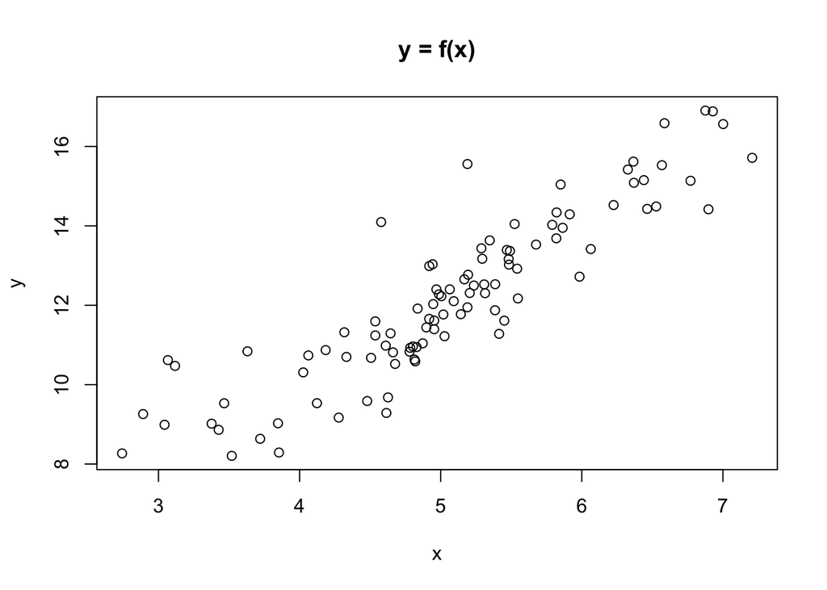

```r
plot(x,y, main = 'y = f(x)')
```

Include information between (x, y).

Our response variable is $y$ is distributed $N(\mu, \sigma^2)$, where
$$\begin{align}
\mu &= 2 + 2*E[x] + E[e] \\[5pt]
\sigma^2 &= 2^Var[x] + Var[e] + 2(2)Cov(x, e)
\end{align}$$

We see that $\mu=$ 12.202405 and $\sigma^2=$ 4.3853958.Let's round the output.

$\mu=$ 12.2

$\sigma^2=$ 4.39

$$y = f(x)$$

# Working with Data

```r
df_all <- read_csv('data/daily_bike_data.csv')
dftemp <- df_all %>% select(cnt, temp)
```

```r
ss_dftemp <- sapply(dftemp,
                    function(x) c(mean(x), min(x), max(x), sd(x))) %>%
  data.frame() %>%
  round(digits = 2)

row.names(ss_dftemp) <- c('mean', 'min', 'max', 'sd')
ss_dftemp %>% knitr::kable(caption = 'Summary Statistics')
```

Summary Statistics

|  | cnt | temp |
| --- | --- | --- |
| mean | 4504.35 | 0.50 |
| min | 22.00 | 0.06 |
| max | 8714.00 | 0.86 |
| sd | 1937.21 | 0.18 |

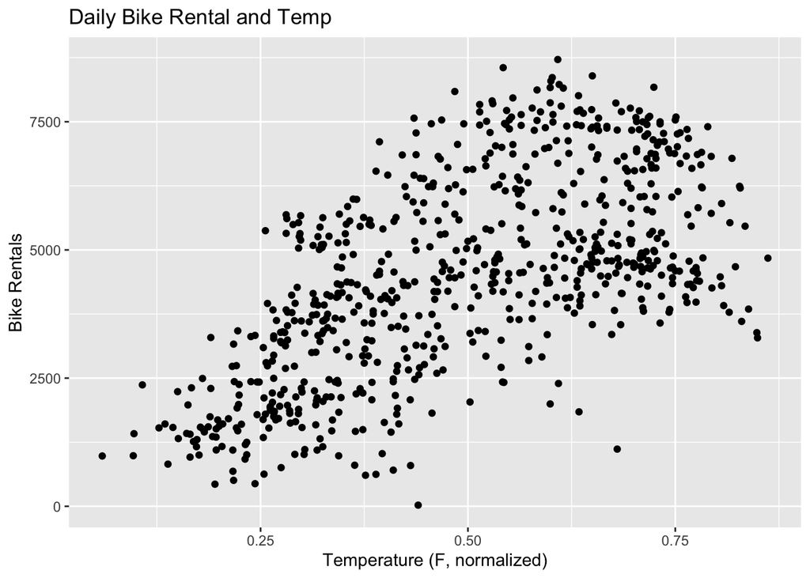

```r
ggplot(dftemp, aes(temp, cnt)) +
  geom_point() +
  labs(title = 'Daily Bike Rental and Temp',
       x = 'Temperature (F, normalized)',
       y = 'Bike Rentals')
```

```r
dftemp <- dftemp %>%
  mutate(temp2 = temp^2)

mod1 <- lm(formula = cnt ~ temp,
           data = dftemp)

mod2 <- lm(formula = cnt ~ temp + temp2,
           data = dftemp)

pred_mod1 <- predict(mod1, dftemp['temp'])
pred_mod2 <- predict(mod2, dftemp[c('temp', 'temp2')])

dftemp <- dftemp %>%
  mutate(cnt_mod1 = pred_mod1,
         cnt_mod2 = pred_mod2)
```

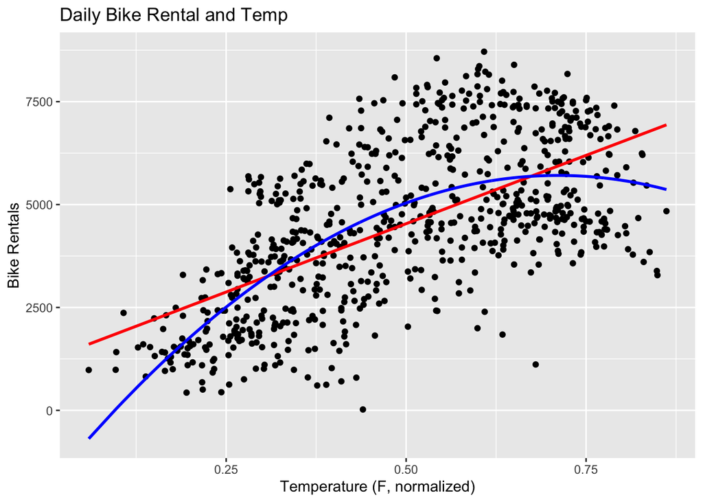

```r
ggplot(dftemp, aes(temp, cnt)) +
  geom_point() +
  geom_line(aes(temp, pred_mod1), colour = 'red', size = 1) +
  geom_line(aes(temp, pred_mod2), colour = 'blue', size = 1) +
  labs(title = 'Daily Bike Rental and Temp',
       x = 'Temperature (F, normalized)',
       y = 'Bike Rentals')
```

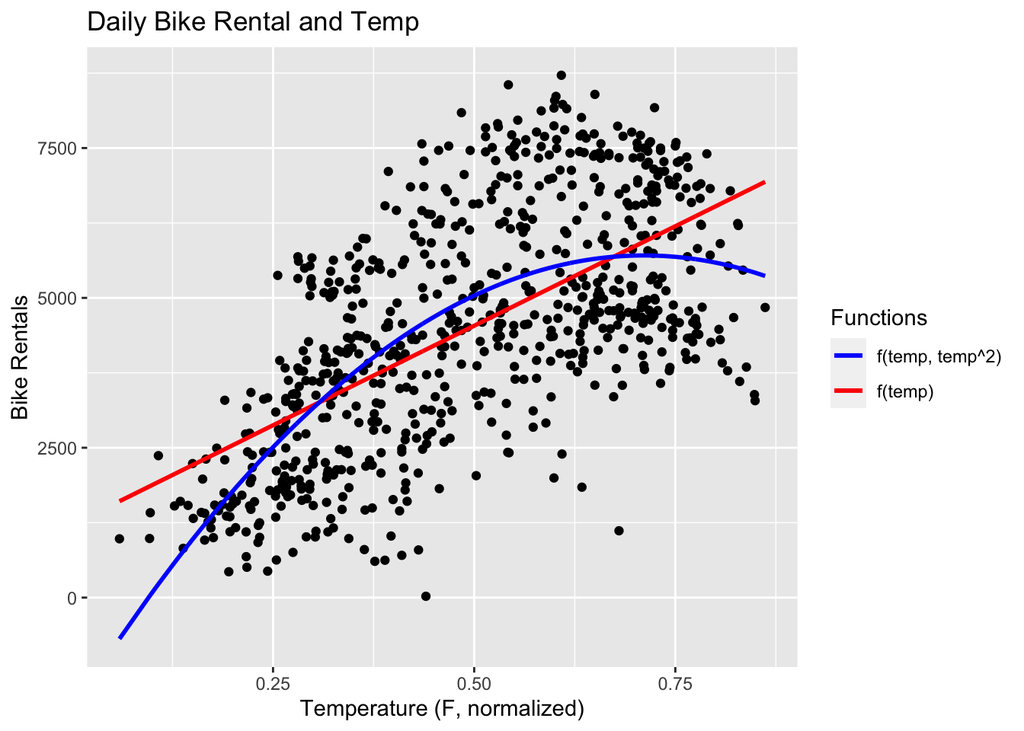

```r
ggplot(dftemp, aes(temp, cnt)) +
  geom_point() +
  geom_line(aes(temp, pred_mod1, color = 'f(temp)'), size = 1) +
  geom_line(aes(temp, pred_mod2, color = 'f(temp, temp^2)'), size = 1) +
  labs(title = 'Daily Bike Rental and Temp',
       x = 'Temperature (F, normalized)',
       y = 'Bike Rentals',
       color = 'Functions') +
  scale_color_manual(values = c('f(temp)' = 'red',
                                'f(temp, temp^2)' = 'blue'))
```